# 03 — LD decay & the candidate-locus window

### G2F maize hybrid panel — averaged-trait vs BLUE-trait BLINK

A significant GWAS SNP is a *tag*, not usually the causal variant: the causal site sits somewhere in the linkage-disequilibrium (LD) block around it. The block's width — set by how fast r² between SNP pairs decays with distance — is the **± window** to scan for candidate genes around each hit. This notebook measures it and applies it, in three steps:

1. **LD decay (full 437K panel)** → derive the **±16 kb** (half-decay) and **±32 kb** (conservative) windows.
2. **Candidate loci per run** → apply the window to the averaged- and BLUE-trait BLINK hits.
3. **Positional concordance** → how much the two runs' loci overlap, at ±16 and ±32 kb.

```python
import warnings, glob
from pathlib import Path
import numpy as np, pandas as pd, matplotlib.pyplot as plt
warnings.filterwarnings("ignore")
%matplotlib inline
plt.rcParams.update({"figure.dpi": 120, "font.size": 10, "axes.grid": True,
                     "grid.alpha": 0.3, "savefig.bbox": "tight"})

PROJECT = Path("/path/to/PLANT_PROJECT")
BFILE   = PROJECT/"longleaf"/"plink_ld"/"5_Genotype_Data_All_Years_plink"   # full 437K, unpruned
PLINK   = "plink"
LDDIR   = PROJECT/"local_experiments"/"ld";              LDDIR.mkdir(parents=True, exist_ok=True)
FIG     = PROJECT/"local_experiments"/"figures";         FIG.mkdir(exist_ok=True)
TAB     = PROJECT/"local_experiments"/"ld_decay_tables"; TAB.mkdir(exist_ok=True)
QC      = PROJECT/"local_experiments"/"qc_check";        QC.mkdir(exist_ok=True)
SNPNAMES = PROJECT/"local_experiments"/"snpnames.csv"

import subprocess
def run_plink(args, sentinel):                # run only if output missing; always print cmd
    print("plink:", " ".join(str(c) for c in [PLINK, *args]))
    if Path(sentinel).exists(): print("  -> present, skipping"); return
    r = subprocess.run([PLINK, *args], capture_output=True, text=True)
    print("  done." if r.returncode == 0 else f"  FAILED: {r.stderr[-300:]}")
def savefig(fig, stem): fig.savefig(FIG/f"{stem}.png", dpi=600); fig.savefig(FIG/f"{stem}.pdf"); print("fig:", stem)
def save_tsv(df, name, index=True): df.to_csv(TAB/name, sep="\t", index=index); print("tsv:", name)
print("ready")
```

```
ready
```

## 1. LD decay on the full 437K panel

**Why the full panel.** LD decay is a property of the *population*, not of whichever markers we test. The GWAS scans on the curated **98,026-SNP** set (MAF/call-rate QC **+ LD-pruning** of the 437,214 PHG calls), but LD-pruning deliberately deletes the high-LD pairs that *define* decay — so measuring decay on the pruned set would deflate it. We therefore estimate decay on the **full 437K** panel. The table below confirms the split is sound: the dropped markers are mostly rare/high-missingness (QC) or redundant in-LD tags (pruning), i.e. exactly what you don't want in a scan but do want for decay.

```python
a = pd.read_csv(SNPNAMES); a.columns = ["chrom","pos","snp"]; keep = set(a.snp)
run_plink(["--bfile", str(BFILE), "--freq", "--missing", "--allow-extra-chr", "--out", str(QC/"full437")],
          sentinel=QC/"full437.frq")
frq = pd.read_csv(QC/"full437.frq", sep=r"\s+"); lm = pd.read_csv(QC/"full437.lmiss", sep=r"\s+")
m = frq[["SNP","MAF"]].merge(lm[["SNP","F_MISS"]], on="SNP")
m["set"] = np.where(m.SNP.isin(keep), "scan set (98K)", "dropped (339K)")
qc = m.groupby("set").apply(lambda g: pd.Series({
        "n_SNPs": len(g), "median_MAF": round(g.MAF.median(),3),
        "pct_MAF<0.05": round((g.MAF<0.05).mean()*100,1),
        "pct_missing>0.10": round((g.F_MISS>0.10).mean()*100,1)})).loc[["scan set (98K)","dropped (339K)"]]
display(qc); save_tsv(qc, "01_marker_set_qc.tsv")
```

```
plink: plink --bfile /path/to/PLANT_PROJECT/longleaf/plink_ld/5_Genotype_Data_All_Years_plink --freq --missing --allow-extra-chr --out /path/to/PLANT_PROJECT/local_experiments/qc_check/full437
  -> present, skipping
```

| set | n_SNPs | median_MAF | pct_MAF<0.05 | pct_missing>0.10 |
| --- | --- | --- | --- | --- |
| scan set (98K) | 98026.0 | 0.238 | 6.7 | 0.0 |
| dropped (339K) | 339188.0 | 0.172 | 29.3 | 8.7 |

```
tsv: 01_marker_set_qc.tsv
```

**plink computes r²** for all SNP pairs within 300 kb, with no r² floor (`--ld-window-r2 0`) so the low-r² tail — which *is* the decay — is kept. We use the **MAF ≥ 0.05** set, standard for LD-decay (rare variants give noisy, downward-biased r²). Python only averages plink's r² into 1 kb bins.

```python
run_plink(["--bfile",str(BFILE),"--maf","0.05","--r2","gz","--ld-window-kb","300",
           "--ld-window","99999","--ld-window-r2","0","--allow-extra-chr","--threads","2",
           "--memory","8000","--out",str(LDDIR/"ld_decay_maf05")], LDDIR/"ld_decay_maf05.ld.gz")

def bin_decay(ld_file, WIN=300, BIN=1):
    nb = WIN//BIN; s = np.zeros(nb); c = np.zeros(nb, dtype=np.int64)
    for ch in pd.read_csv(ld_file, sep=r"\s+", usecols=["BP_A","BP_B","R2"], chunksize=2_000_000):
        d = (ch.BP_B.to_numpy()-ch.BP_A.to_numpy())/1000.0; r2 = ch.R2.to_numpy()
        ok = (d>0)&(d<WIN); b = (d[ok]//BIN).astype(int); np.add.at(s,b,r2[ok]); np.add.at(c,b,1)
    mid=(np.arange(nb)+0.5)*BIN; mr=np.where(c>0,s/np.maximum(c,1),np.nan)
    return pd.DataFrame({"dist_kb":mid,"mean_r2":mr,"n_pairs":c}).dropna()

decay = bin_decay(LDDIR/"ld_decay_maf05.ld.gz")
save_tsv(decay.round({"dist_kb":1,"mean_r2":4}), "02_ld_decay_binned.tsv", index=False)
print(f"binned {int(decay.n_pairs.sum()):,} SNP pairs (MAF≥0.05)")
```

```
plink: plink --bfile /path/to/PLANT_PROJECT/longleaf/plink_ld/5_Genotype_Data_All_Years_plink --maf 0.05 --r2 gz --ld-window-kb 300 --ld-window 99999 --ld-window-r2 0 --allow-extra-chr --threads 2 --memory 8000 --out /path/to/PLANT_PROJECT/local_experiments/ld/ld_decay_maf05
  -> present, skipping
```

```
tsv: 02_ld_decay_binned.tsv
binned 22,819,429 SNP pairs (MAF≥0.05)
```

```python
from scipy.optimize import curve_fit
N_IND = 4928   # individuals in the LD panel (PLINK .fam)

# Hill & Weir (1988) expected-r² decay (Remington et al. 2001 form), with a free BACKGROUND term c.
# This related/structured hybrid panel's LD plateaus well above 0, so vanilla Hill-Weir (which
# assumes decay to ~0) fits poorly; the background form fits well. Fit one curve per SNP set and
# read the half-decay off the FITTED curve (so it does not depend on the 300 kb distance cap).
def hill_weir(dbp, rho, c):
    C  = rho * dbp
    hw = ((10+C)/((2+C)*(11+C))) * (1 + ((3+C)*(12+12*C+C**2))/(N_IND*(2+C)*(11+C)))
    return c + (1.0-c)*hw

def fit_decay(d):
    x = d.dist_kb.values*1000.0; y = d.mean_r2.values
    (rho, c), _ = curve_fit(hill_weir, x, y, p0=[1e-4, 0.12], bounds=([1e-8,0],[1e-2,0.6]), maxfev=60000)
    yhat = hill_weir(x, rho, c); R2 = 1 - ((y-yhat)**2).sum()/((y-y.mean())**2).sum()
    grid = np.arange(1, 300001); fg = hill_weir(grid, rho, c)
    short = fg[0]; half_lvl = (short + c)/2; half = grid[np.argmax(fg < half_lvl)]/1000.0
    return dict(short_r2=short, background=c, half_kb=half, R2=R2, rho=rho)

F = fit_decay(decay)
thr = pd.DataFrame([{"set":"MAF≥0.05", "short_range_r2":round(F["short_r2"],3),
                     "background_r2":round(F["background"],3),
                     "half_decay_kb":round(F["half_kb"],1), "fit_R2":round(F["R2"],3)}]).set_index("set")
display(thr); save_tsv(thr, "03_ld_thresholds.tsv")

WINDOW   = int(round(F["half_kb"]))   # half-decay
WINDOW_C = int(round(2*WINDOW))       # conservative (2× half-decay)
print(f"Hill-Weir half-decay (fitted) = {F['half_kb']:.1f} kb  (fit R²={F['R2']:.2f}, background r²={F['background']:.2f})")
print(f"==> WINDOW = ±{WINDOW} kb (half-decay) ; CONSERVATIVE = ±{WINDOW_C} kb (2× half-decay)")
```

| set | short_range_r2 | background_r2 | half_decay_kb | fit_R2 |
| --- | --- | --- | --- | --- |
| MAF≥0.05 | 0.542 | 0.16 | 15.7 | 0.897 |

```
tsv: 03_ld_thresholds.tsv
Hill-Weir half-decay (fitted) = 15.7 kb  (fit R²=0.90, background r²=0.16)
==> WINDOW = ±16 kb (half-decay) ; CONSERVATIVE = ±32 kb (2× half-decay)
```

```
fig: ld01_decay_curve
```

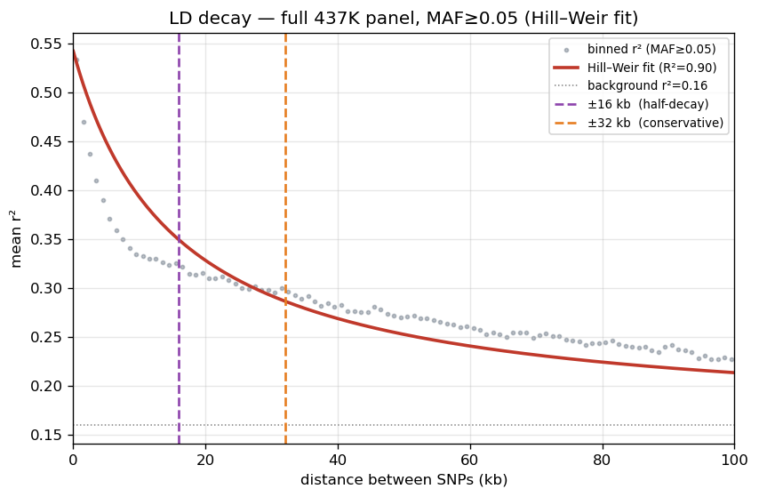

```python
grid = np.arange(1, 100001)
fig, ax = plt.subplots(figsize=(8, 5))
sel = decay.dist_kb <= 100
ax.scatter(decay.dist_kb[sel], decay.mean_r2[sel], s=6, color="#2c3e50", alpha=0.30, label="binned r² (MAF≥0.05)")
ax.plot(grid/1000, hill_weir(grid, F["rho"], F["background"]), lw=2.2, color="#c0392b",
        label=f"Hill–Weir fit (R²={F['R2']:.2f})")
ax.axhline(F["background"], color="grey", ls=":", lw=0.9, label=f"background r²={F['background']:.2f}")
ax.axvline(WINDOW,   ls="--", lw=1.6, color="#8e44ad", label=f"±{WINDOW} kb  (half-decay)")
ax.axvline(WINDOW_C, ls="--", lw=1.6, color="#e67e22", label=f"±{WINDOW_C} kb  (conservative)")
ax.set_xlim(0, 100); ax.set_xlabel("distance between SNPs (kb)"); ax.set_ylabel("mean r²")
ax.set_title("LD decay — full 437K panel, MAF≥0.05 (Hill–Weir fit)")
ax.legend(fontsize=8); savefig(fig, "ld01_decay_curve"); plt.show()
```

## 2. Candidate loci per run — averaged vs BLUE BLINK

Two BLINK runs, identical genotypes and settings, differing **only** in the phenotype: environment-**averaged** (naive) vs two-stage **BLUE** (the env-confounding fix). For each, take the Bonferroni-significant SNPs (p < 0.05 / 98026), expand each to ±16 kb, and merge overlapping intervals per chromosome into **candidate loci**.

```python
BONF = 0.05/98026
TRAITS = ["yield","anthesis","silking","ASI"]
STRESS = ["NO_STRESS","HEAT_STRESSED","DROUGHT_STRESSED","HEAT_DROUGHT_STRESSED"]
CONDS  = [f"{t}_{s}" for t in TRAITS for s in STRESS]
OLD = PROJECT/"gapit"/"results"                    # averaged-trait BLINK
NEW = PROJECT/"local_experiments"/"results_blue"   # BLUE-trait BLINK

def sig_snps(base, cond, thr=BONF):
    g = [x for x in glob.glob(str(Path(base)/f"{cond}_BLINK"/"GAPIT.Association.GWAS_Results.BLINK.*.csv"))
         if "(NYC)" not in x]
    if not g: return pd.DataFrame(columns=["SNP","Chr","Pos"])
    df = pd.read_csv(g[0], usecols=["SNP","Chr","Pos","P.value"])
    for c in ["Chr","Pos","P.value"]: df[c] = pd.to_numeric(df[c], errors="coerce")
    return df[df["P.value"] < thr].dropna(subset=["Pos"])

def merge_intervals(df, w):                         # per-chrom merged [pos-w, pos+w] intervals
    iv = {}
    for chrom, g in df.groupby("Chr"):
        xs = sorted((p-w, p+w) for p in g.Pos); out=[]; cs,ce = xs[0]
        for s,e in xs[1:]:
            if s<=ce: ce=max(ce,e)
            else: out.append((cs,ce)); cs,ce=s,e
        out.append((cs,ce)); iv[int(chrom)] = out
    return iv

w = WINDOW*1000
rows = []
for c in CONDS:
    so, sn = sig_snps(OLD,c), sig_snps(NEW,c)
    A, B = merge_intervals(so,w), merge_intervals(sn,w)
    spanA = sum(e-s for v in A.values() for s,e in v)/1e6
    spanB = sum(e-s for v in B.values() for s,e in v)/1e6
    rows.append({"condition":c, "n_sig_avg":len(so), "n_loci_avg":sum(map(len,A.values())), "span_Mb_avg":round(spanA,2),
                 "n_sig_blue":len(sn), "n_loci_blue":sum(map(len,B.values())), "span_Mb_blue":round(spanB,2)})
fp = pd.DataFrame(rows).set_index("condition")
display(fp); save_tsv(fp, "04_footprint_by_condition.tsv")
T = fp.sum(numeric_only=True)
print(f"\nTOTAL @ ±{WINDOW} kb — averaged: {int(T.n_loci_avg)} loci / {T.span_Mb_avg:.1f} Mb"
      f"  |  BLUE: {int(T.n_loci_blue)} loci / {T.span_Mb_blue:.1f} Mb")
```

| condition | n_sig_avg | n_loci_avg | span_Mb_avg | n_sig_blue | n_loci_blue | span_Mb_blue |
| --- | --- | --- | --- | --- | --- | --- |
| yield_NO_STRESS | 29 | 29 | 0.93 | 25 | 25 | 0.80 |
| yield_HEAT_STRESSED | 18 | 18 | 0.58 | 12 | 12 | 0.38 |
| yield_DROUGHT_STRESSED | 4 | 4 | 0.13 | 5 | 5 | 0.16 |
| yield_HEAT_DROUGHT_STRESSED | 16 | 16 | 0.51 | 9 | 9 | 0.29 |
| anthesis_NO_STRESS | 108 | 99 | 3.20 | 62 | 62 | 1.98 |
| anthesis_HEAT_STRESSED | 33 | 33 | 1.06 | 36 | 35 | 1.12 |
| anthesis_DROUGHT_STRESSED | 3 | 3 | 0.10 | 14 | 14 | 0.45 |
| anthesis_HEAT_DROUGHT_STRESSED | 47 | 46 | 1.47 | 38 | 38 | 1.22 |
| silking_NO_STRESS | 46 | 46 | 1.47 | 86 | 85 | 2.73 |
| silking_HEAT_STRESSED | 32 | 32 | 1.02 | 17 | 17 | 0.54 |
| silking_DROUGHT_STRESSED | 12 | 12 | 0.38 | 4 | 4 | 0.13 |
| silking_HEAT_DROUGHT_STRESSED | 45 | 45 | 1.44 | 52 | 52 | 1.66 |
| ASI_NO_STRESS | 25 | 25 | 0.80 | 21 | 21 | 0.67 |
| ASI_HEAT_STRESSED | 16 | 16 | 0.51 | 22 | 22 | 0.70 |
| ASI_DROUGHT_STRESSED | 8 | 8 | 0.26 | 6 | 6 | 0.19 |
| ASI_HEAT_DROUGHT_STRESSED | 11 | 11 | 0.35 | 8 | 8 | 0.26 |

```
tsv: 04_footprint_by_condition.tsv

TOTAL @ ±16 kb — averaged: 443 loci / 14.2 Mb  |  BLUE: 415 loci / 13.3 Mb
```

```
fig: ld02_footprint_by_condition
```

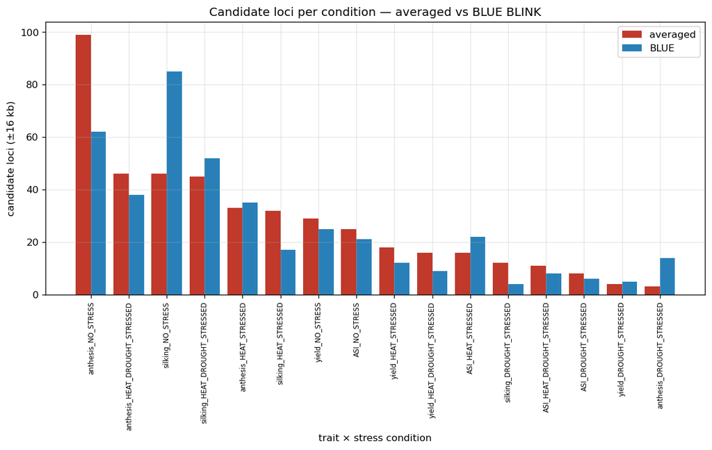

```python
order = fp.sort_values("n_loci_avg", ascending=False).index
x = np.arange(len(order)); bw = 0.4
fig, ax = plt.subplots(figsize=(12, 5))
ax.bar(x-bw/2, fp.loc[order,"n_loci_avg"],  bw, label="averaged", color="#c0392b")
ax.bar(x+bw/2, fp.loc[order,"n_loci_blue"], bw, label="BLUE",     color="#2980b9")
ax.set_xticks(x); ax.set_xticklabels(order, rotation=90, fontsize=7)
ax.set_ylabel(f"candidate loci (±{WINDOW} kb)"); ax.set_xlabel("trait × stress condition")
ax.set_title("Candidate loci per condition — averaged vs BLUE BLINK"); ax.legend()
savefig(fig, "ld02_footprint_by_condition"); plt.show()
```

The two runs produce **comparable numbers** of candidate loci. Whether they point at the *same* places is the next question.

## 3. Positional concordance — averaged vs BLUE (±16 and ±32 kb)

Do the two runs nominate the **same genomic regions**? Two views, both reported below:

- **`*_snps`** — raw significant-SNP counts and exact shared SNP IDs. **Window-independent.**
- **`*_loci_16` / `*_loci_32`** — significant SNPs expanded by ±window and merged into candidate regions; `shared` = regions overlapping between runs.

Note on merged loci: widening the window can only **merge** nearby SNPs into fewer regions, so `*_loci_32 ≤ *_loci_16` *by construction* (it's merging, not a change in signal), while `shared` can only rise as matching gets more lenient. The genomic bp covered still grows with the window.

```python
def overlap_count(A, B):                            # # of A-intervals overlapping any B-interval
    h = 0
    for ch, ivA in A.items():
        ivB = B.get(ch, [])
        for s,e in ivA:
            if any(not(e<bs or be<s) for bs,be in ivB): h += 1
    return h

rows = []
for c in CONDS:
    so, sn = sig_snps(OLD,c), sig_snps(NEW,c)
    row = {"condition": c,
           "avg_snps": len(so), "blue_snps": len(sn),                 # window-independent
           "shared_snps": len(set(so.SNP) & set(sn.SNP))}             # exact SNP-ID overlap
    for wkb in (WINDOW, WINDOW_C):
        A, B = merge_intervals(so, wkb*1000), merge_intervals(sn, wkb*1000)
        na, nb = sum(map(len,A.values())), sum(map(len,B.values()))
        sh = overlap_count(A, B)
        row[f"avg_loci_{wkb}"]=na; row[f"blue_loci_{wkb}"]=nb; row[f"shared_{wkb}"]=sh
    rows.append(row)
con = pd.DataFrame(rows).set_index("condition")
display(con); save_tsv(con, "05_concordance_by_position.tsv")

T = con.sum(numeric_only=True)
print("\n=== concordance (totals) ===")
print(f"  SNPs (window-independent): averaged {int(T.avg_snps)} / BLUE {int(T.blue_snps)} "
      f"sig SNPs; shared exactly {int(T.shared_snps)} ({100*T.shared_snps/max(T.blue_snps,1):.1f}% of BLUE)")
for wkb in (WINDOW, WINDOW_C):
    na, nb, sh = int(T[f"avg_loci_{wkb}"]), int(T[f"blue_loci_{wkb}"]), int(T[f"shared_{wkb}"])
    print(f"  ±{wkb} kb merged loci : shared {sh}  of  averaged {na} / BLUE {nb}"
          f"  ({100*sh/max(nb,1):.1f}% of BLUE loci overlap an averaged locus)")
```

| condition | avg_snps | blue_snps | shared_snps | avg_loci_16 | blue_loci_16 | shared_16 | avg_loci_32 | blue_loci_32 | shared_32 |
| --- | --- | --- | --- | --- | --- | --- | --- | --- | --- |
| yield_NO_STRESS | 29 | 25 | 1 | 29 | 25 | 1 | 29 | 25 | 1 |
| yield_HEAT_STRESSED | 18 | 12 | 0 | 18 | 12 | 0 | 18 | 12 | 0 |
| yield_DROUGHT_STRESSED | 4 | 5 | 0 | 4 | 5 | 0 | 4 | 5 | 0 |
| yield_HEAT_DROUGHT_STRESSED | 16 | 9 | 1 | 16 | 9 | 1 | 16 | 9 | 1 |
| anthesis_NO_STRESS | 108 | 62 | 0 | 99 | 62 | 2 | 97 | 62 | 2 |
| anthesis_HEAT_STRESSED | 33 | 36 | 0 | 33 | 35 | 0 | 33 | 35 | 0 |
| anthesis_DROUGHT_STRESSED | 3 | 14 | 1 | 3 | 14 | 1 | 3 | 14 | 1 |
| anthesis_HEAT_DROUGHT_STRESSED | 47 | 38 | 1 | 46 | 38 | 1 | 46 | 38 | 1 |
| silking_NO_STRESS | 46 | 86 | 1 | 46 | 85 | 2 | 46 | 85 | 2 |
| silking_HEAT_STRESSED | 32 | 17 | 0 | 32 | 17 | 0 | 32 | 17 | 0 |
| silking_DROUGHT_STRESSED | 12 | 4 | 3 | 12 | 4 | 3 | 12 | 4 | 3 |
| silking_HEAT_DROUGHT_STRESSED | 45 | 52 | 0 | 45 | 52 | 0 | 45 | 52 | 1 |
| ASI_NO_STRESS | 25 | 21 | 3 | 25 | 21 | 4 | 25 | 21 | 5 |
| ASI_HEAT_STRESSED | 16 | 22 | 1 | 16 | 22 | 1 | 16 | 22 | 1 |
| ASI_DROUGHT_STRESSED | 8 | 6 | 3 | 8 | 6 | 3 | 8 | 6 | 3 |
| ASI_HEAT_DROUGHT_STRESSED | 11 | 8 | 0 | 11 | 8 | 0 | 11 | 8 | 0 |

```
tsv: 05_concordance_by_position.tsv

=== concordance (totals) ===
  SNPs (window-independent): averaged 453 / BLUE 417 sig SNPs; shared exactly 15 (3.6% of BLUE)
  ±16 kb merged loci : shared 19  of  averaged 443 / BLUE 415  (4.6% of BLUE loci overlap an averaged locus)
  ±32 kb merged loci : shared 21  of  averaged 441 / BLUE 415  (5.1% of BLUE loci overlap an averaged locus)
```

```
fig: ld03_concordance_by_position
```

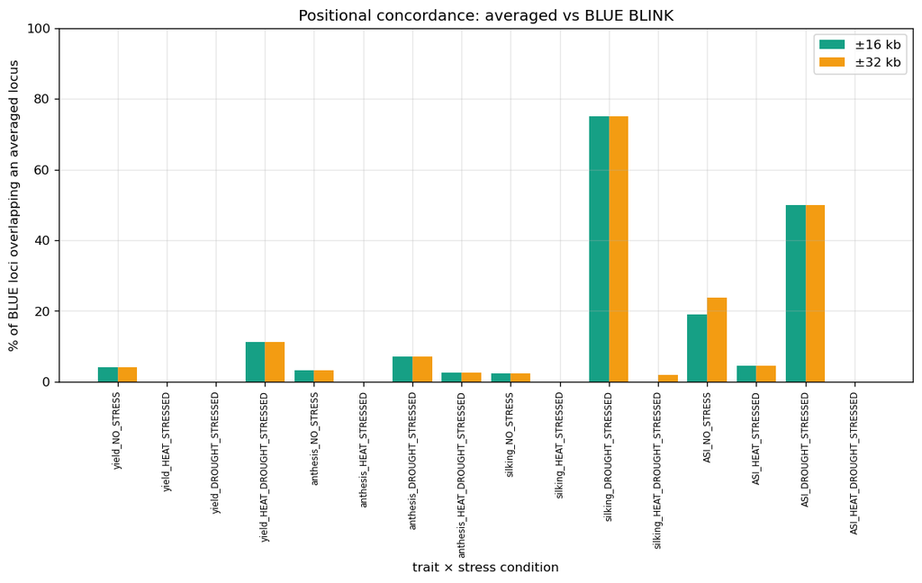

```python
# shared fraction (of BLUE loci) per condition at both windows
fr16 = (con[f"shared_{WINDOW}"]   / con[f"blue_loci_{WINDOW}"].replace(0,np.nan) * 100)
fr32 = (con[f"shared_{WINDOW_C}"] / con[f"blue_loci_{WINDOW_C}"].replace(0,np.nan) * 100)
order = con.index
x = np.arange(len(order)); bw = 0.4
fig, ax = plt.subplots(figsize=(12, 5))
ax.bar(x-bw/2, fr16.loc[order].fillna(0), bw, label=f"±{WINDOW} kb",   color="#16a085")
ax.bar(x+bw/2, fr32.loc[order].fillna(0), bw, label=f"±{WINDOW_C} kb", color="#f39c12")
ax.set_xticks(x); ax.set_xticklabels(order, rotation=90, fontsize=7)
ax.set_ylabel("% of BLUE loci overlapping an averaged locus"); ax.set_xlabel("trait × stress condition")
ax.set_title("Positional concordance: averaged vs BLUE BLINK"); ax.set_ylim(0,100); ax.legend()
savefig(fig, "ld03_concordance_by_position"); plt.show()
```

**Result.** Even at the lenient ±32 kb window, only a small fraction of loci are shared — the averaged and BLUE runs nominate **almost disjoint** sets of regions. Identical genotypes and settings; the only difference is how the trait value was built. So BLINK's nominated loci are **highly sensitive to phenotype construction** in this panel: the locus *count* is stable, the locus *positions* are not.

## Summary

- **Window.** LD decay on the full 437K panel gives a stable half-decay of **~16 kb** → primary candidate window **±16 kb**, conservative **±32 kb**. Use these for snpEff `-ud` / candidate-gene scans. (Absolute r²<0.2 is unreliable here — elevated background LD.)
- **Per run.** Averaged and BLUE BLINK give comparable candidate-locus counts.
- **Concordance.** They overlap on only a small fraction of positions even at ±32 kb — BLINK loci are highly sensitive to phenotype construction, so that choice must be fixed and justified before the loci are treated as findings.

Artifacts: `figures/ld01–ld03*.{png@600dpi,pdf}`; `ld_decay_tables/01–05*.tsv`.